# Determinants of Police Body Camera Usage

Alex Khater, Rajeev Koneru, and Cora Martin

2022-12-14

### Introduction

In a 2014 investigation, The Washington Post reported that the FBI had been under-counting fatal police shootings by more than half. An eighteen year-old Michael Brown was killed by police in St. Louis, Missouri, shining a light on the issue of police brutality in the United States. Relying on news, social media, and police reports, the Washington Post compiled a comprehensive list of police shootings from 2015 to 2022 to amend the issue of under-counting police killings of civilians. Police brutality stems from a lack of accountability. The police force is consistently protected from the consequences of violence, regardless of the use of such tools of accountability as police body cameras. We studied the use of body cameras in police shootings to understand whether the use of body cameras was more common in one state over another. More specifically, we asked: within our data set of 5,720 observations of police shootings from 2015 to 2022 in the United States, is there a correlation between the U.S. state of observation and whether a body camera was turned on during the shooting? We found that the use of body cameras during fatal police shootings certainly varies by state, pointing to the conclusion that state policy plays a role in whether body cameras are turned on during active police duty.

This data set includes information on every fatal police shooting from January 1, 2015 to the present. It is updated regularly by the Washington Post. After accounting for null values, the data set we are working with has 5,720 observations. Below we have provided a single sample observation:

| Name | Date | Manner of Death | Armed | Age | Gender | Race | City |
| --- | --- | --- | --- | --- | --- | --- | --- |
| Tim Elliot | 10/04/2022 | Shot | Gun | 53 | M | A | Shelton |

| State | Signs of Mental Illness | Threat Level | Flee | Body Camera | Longitude | Latitude | Is Geocoding Exact? |
| --- | --- | --- | --- | --- | --- | --- | --- |
| WA | 1 | TRUE | Not fleeing | FALSE | -123 | 47.2 | TRUE |

The total number of observations:

```
## [1] 5720
```

Some of the Post’s key findings from the data set include:

1. Overall, police nationwide kill approximately 1,000 civilians annually.
2. Black people are killed by police at a higher rate than White people. In absolute numbers, the White population is killed most often by police. Black people, accounting for less than 13 percent of the population, are killed more than twice the rate of White people.
3. The majority of victims are male and between the ages of 20 and 40 years.
4. Police shootings occur in every state. In cities, they are more frequent. The states with the highest rates of shootings (considering state population) are New Mexico, Alaska, and Oklahoma.

### Midterm Recap

These findings are the result of previous research by the Washington Post. One of the data set’s limitations is the absence of data on populations at the time of the observation. This information would be valuable for any type of racial injustice analysis. The research we gathered through the EDA began with very basic analyses. A univariate example and a multivariate example are given below:

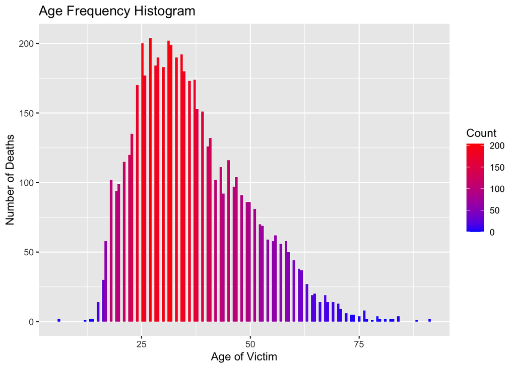

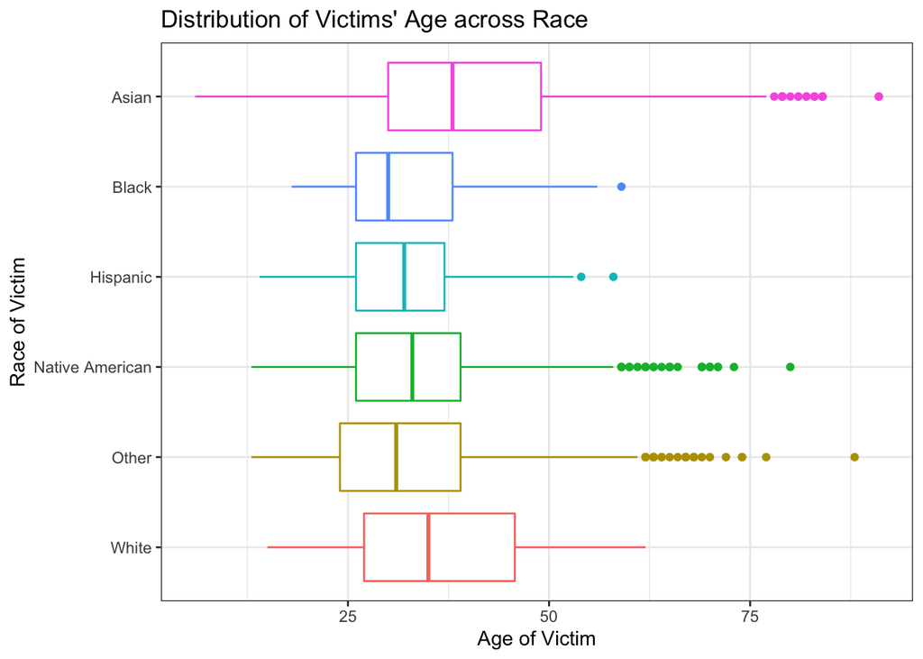

After performing a sufficient amount of exploratory data analysis, we decided we wanted to ask a state- and region-based question. Performing a more comparative analysis using this data set could help us understand why police shootings occur in some states over others. This required us to divide the data in a new way. For data visualization purposes, we chose to divide each state into regions. However, our main focus will rely on state-by-state comparative analysis. The following regional subsets include:

[output not shown]

Fatal shootings in the Northwest United States:

```
## [1] 1551
```

Fatal shootings in the Southwest United States:

```
## [1] 1058
```

Fatal shootings in the Midwest United States:

```
## [1] 955
```

Fatal shootings in the Southeast United States:

```
## [1] 1668
```

Fatal shootings in the Northeast United States:

```
## [1] 488
```

After dividing up the data set, we decided to spotlight the body camera variable. This column in the csv file asked whether the body camera was turned on or off during the fatal police shooting. The data was compiled from official police records, completed by the officers on site. In the Washington Post’s brief article introducing the data set and examining some of the most interesting findings, there was no mention of the body camera variable. This provided us an opportunity to create a relevant, meaningful research project on a little-studied aspect of police work. Our final research question is as follows:

Within our data set of 5,720 observations of police shootings from 2015 to 2022 in the United States, is there a correlation between the U.S. state of observation and whether a body camera was turned on during the shooting?

Number of fatal shootings where the body camera was on:

```
##   body_camera   n
## 1        TRUE 905
```

Number of fatal shootings where the body camera was off:

[output not shown]

We created some figures to visualize body camera use by state and region. In the below bar graph, TRUE signifies a police body camera that was on, while FALSE indicates the body camera was off:

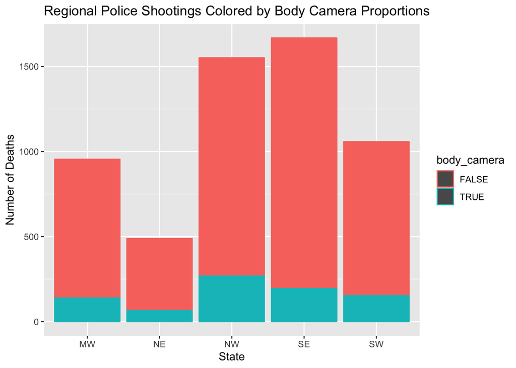

A very important variable allowed us to study body camera use variation by state. This variable is stbcp, or the proportion of shootings when a police body camera was turned on by state. We first checked our data for normality. Because the plot below is relatively linear, we concluded this data is close enough to normality for our purposes.

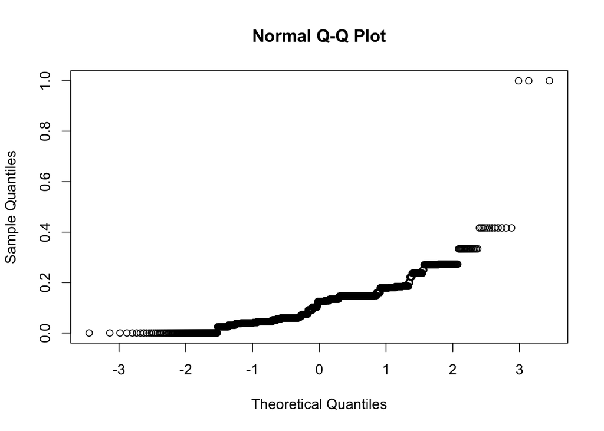

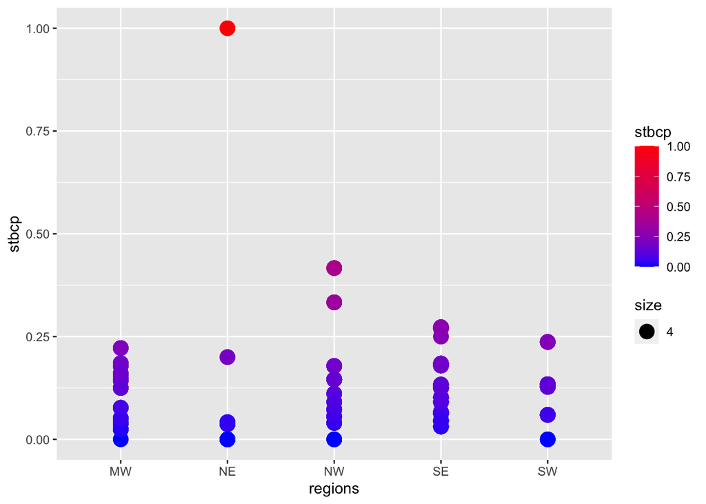

We performed a chi-square test to understand whether there is a significant difference between the proportions of body cameras being on during fatal shootings each state.

$H_{0}$: There is no significant differences between US States in the proportion of body cameras being turned on during police shootings

$H_{A}$: There is a significant difference between US State in the proportion of body cameras being turned on during police shootings

Significance Level: $\alpha = 0.05"$

```
##    Min. 1st Qu.  Median    Mean 3rd Qu.    Max.
##   0.000   0.051   0.125   0.113   0.146   1.000
```

```
##
##  Pearson's Chi-squared test
##
## data:  contable
## X-squared = 66994, df = 1900, p-value <2e-16
```

With a p-value of less 2e-16, we easily pass our significance level of alpha=0.05 and have shown that there exists significant differences between different states’ proportions of body camera usage during fatal police shootings. The challenge now becomes, what is causing this variation in state use of body cameras during active police work? We intend to delve into the reasons why there are differences and research what factors may explain these differences between states. This will require understanding state laws and policies regarding the use of police body cameras. We must also understand the police force funding and other potential restrictions on the proper use of body cameras.

### Part 4: Investigating Causality

Now let us begin testing our new variables Studying the use of body cameras in police work is an important topic of study for data-driven policy research in the United States. We hope to be able to apply this correlation between the U.S. state of observation and whether the body camera was on or off during the shooting to one of the four variables we have collection: US region, police funding, number of enforcement officers, or state law.

```
## # A tibble: 6 × 17
## # Groups:   state [6]
##   state month year  regions spendpc bclaw marg2020 le_per_1…¹  stbcp gen.p smi.p
##   <chr> <chr> <chr> <fct>     <dbl> <dbl>    <dbl>      <dbl>  <dbl> <dbl> <dbl>
## 1 WA    10    2022  NW          608     0       19       320. 0.0556 0.917 0.5
## 2 OR    10    2022  NW          736     0       16       284. 0.04   0.96  0.36
## 3 KS    10    2022  MW          553     0      -15       467. 0.125  0.938 0.188
## 4 CA    10    2022  NW          981     0       29       378. 0.146  0.944 0.255
## 5 CO    10    2022  NW          664     0       14       417. 0.0727 0.982 0.164
## 6 OK    10    2022  SW          487     0      -33       410. 0.128  1     0.277
## # … with 6 more variables: flee.p <dbl>, att.p <dbl>, armed.p <dbl>,
## #   MoD.p <dbl>, age.avg <dbl>, Non_White_prop <dbl>, and abbreviated variable
## #   name ¹le_per_100k
```

Number of observations:

```
## [1] 1763
```

#### State laws on police body cameras

The following figure depicts the relationship between the number stbcp and body camera laws. As we can see, states with high levels of stbcp do not have laws governing body camera usage, represented by a value of 1.00 on the y-axis. This suggests that state laws are not good predictors of body camera usage. Later on we will test this theory with a regression model.

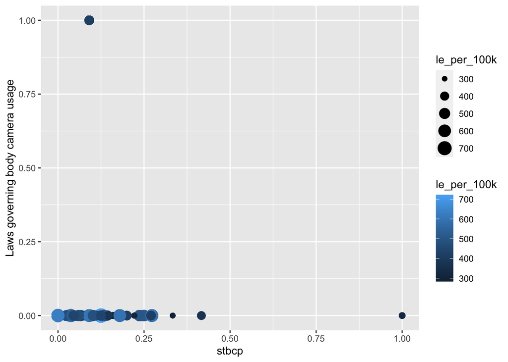

#### Number of law enforcement officers

The following figure depicts the relationship between law enforcement officers per 100,000 citizens and stbcp. Again, it is difficult to see any correlation between high stbcp levels and high levels of enforcement officers. This means two out of four of our models seem not to be predictive, given this visualization.

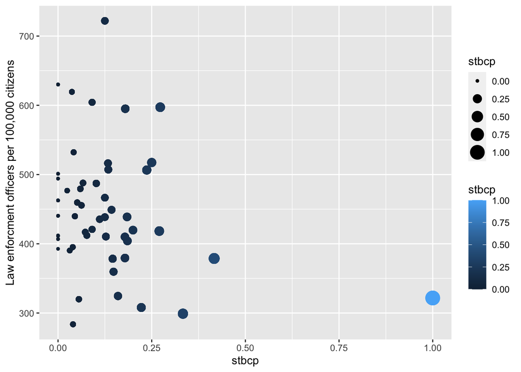

#### Political affiliation

This figure depicts the relationship between the 2020 US presidential election margin and stbcp. Although this is an interesting finding, it again proves that the socio-political variable of 2020 election margin is not predictive of stbcp. It does show that across party lines, stbcp levels are quite similar across states.

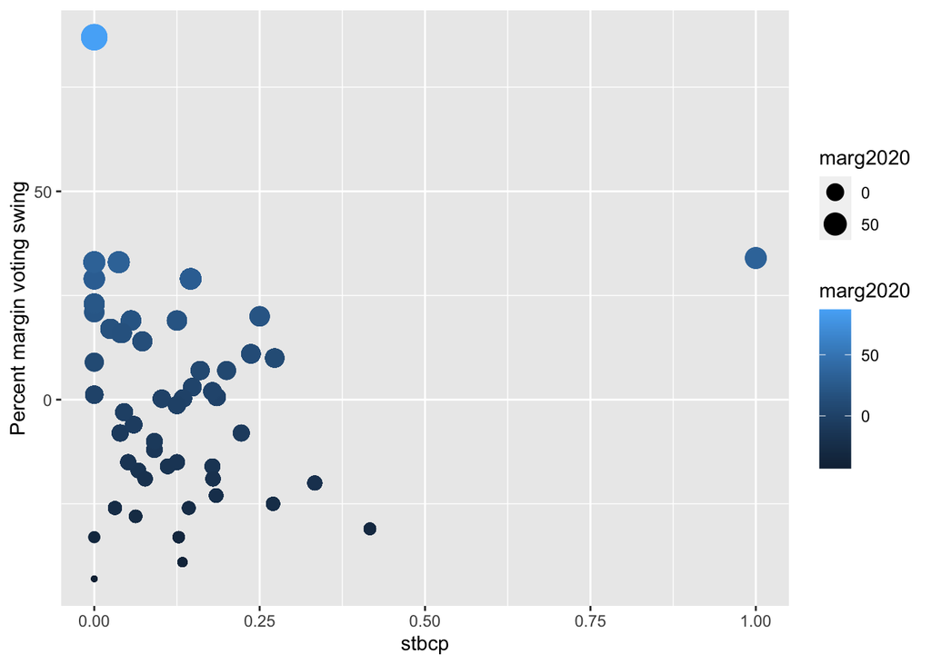

#### State spending on policing

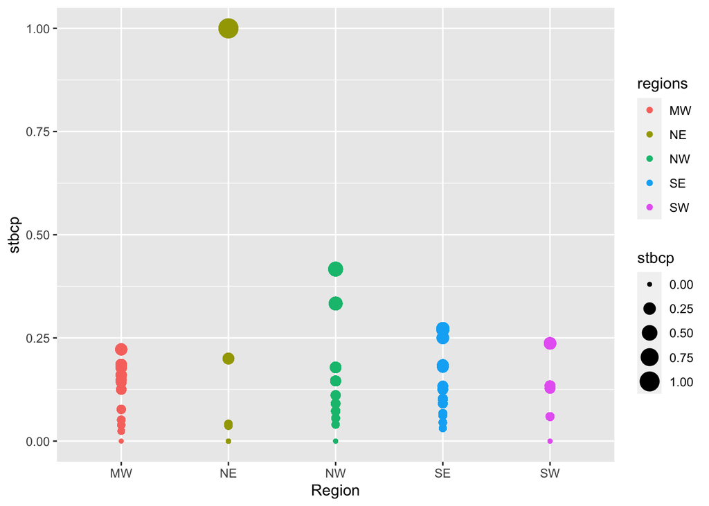

#### Model 1

Now we have seen some basic visualization and we are familiar with the data. Let’s begin creating multiple linear regression model with our new variables. The first model is a simple multiple linear regression model that uses all of the new variables, as well as the region variable.

```
##
## Call:
## lm(formula = stbcp ~ (marg2020 + bclaw + regions + le_per_100k +
##     spendpc), data = FD)
##
## Residuals:
##     Min      1Q  Median      3Q     Max
## -0.1649 -0.0532  0.0032  0.0318  0.9610
##
## Coefficients:
##              Estimate Std. Error t value Pr(>|t|)
## (Intercept)  1.05e-01   1.53e-02    6.84  1.1e-11 ***
## marg2020    -6.23e-04   1.66e-04   -3.76  0.00018 ***
## bclaw       -3.43e-02   1.44e-02   -2.38  0.01734 *
## regionsNE   -4.59e-02   9.28e-03   -4.94  8.4e-07 ***
## regionsNW    3.64e-02   7.95e-03    4.58  4.9e-06 ***
## regionsSE    2.40e-02   6.44e-03    3.73  0.00020 ***
## regionsSW    5.96e-03   6.75e-03    0.88  0.37738
## le_per_100k -6.46e-05   3.67e-05   -1.76  0.07900 .
## spendpc      3.74e-05   2.01e-05    1.86  0.06262 .
## ---
## Signif. codes:  0 '***' 0.001 '**' 0.01 '*' 0.05 '.' 0.1 ' ' 1
##
## Residual standard error: 0.0787 on 1754 degrees of freedom
## Multiple R-squared:  0.114,  Adjusted R-squared:  0.11
## F-statistic: 28.3 on 8 and 1754 DF,  p-value: <2e-16
```

```
##             GVIF Df GVIF^(1/(2*Df))
## marg2020    2.99  1            1.73
## bclaw       1.09  1            1.04
## regions     5.43  4            1.24
## le_per_100k 2.19  1            1.48
## spendpc     3.97  1            1.99
```

```
##        res
## 1 -0.07591
## 2 -0.10046
## 3  0.02029
## 4  0.01029
## 5 -0.05770
## 6  0.00461
```

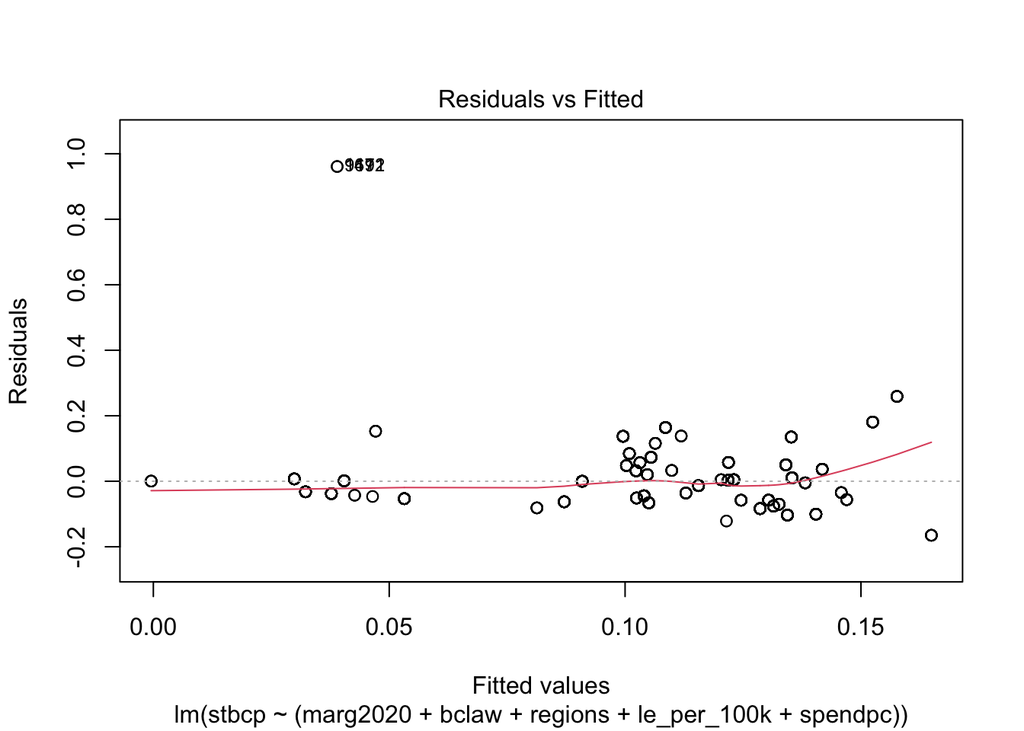

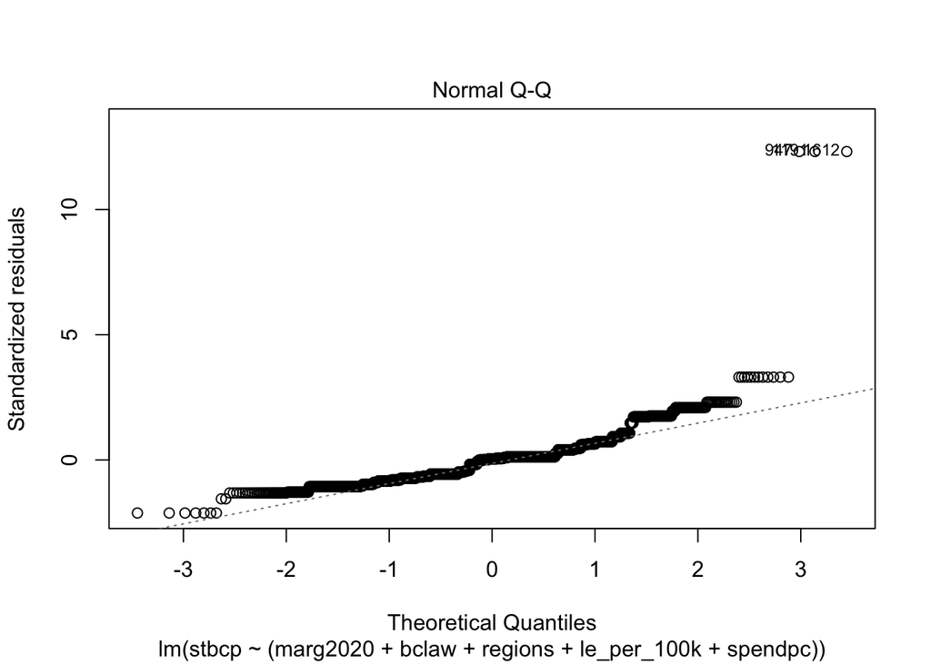

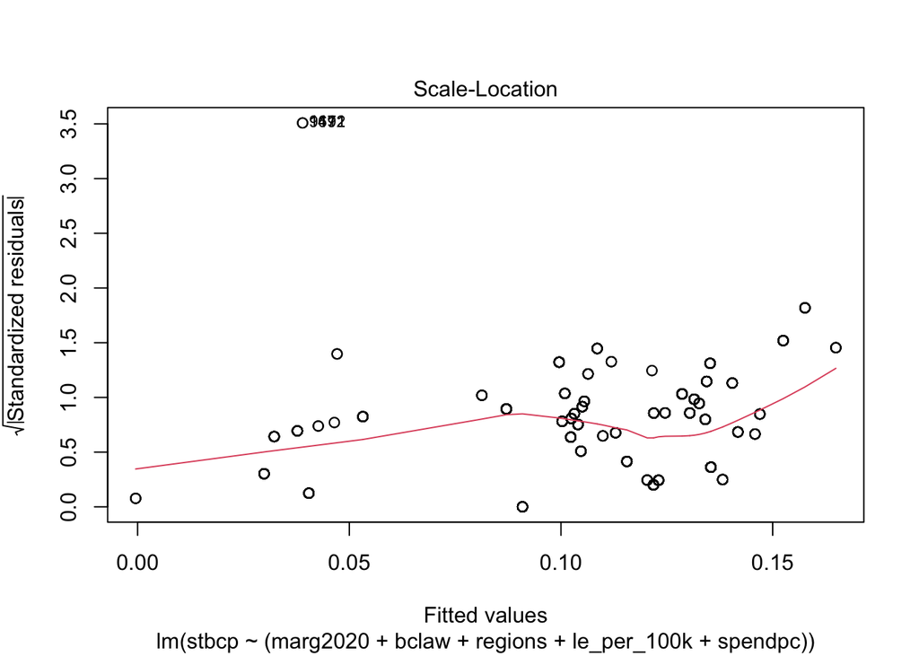

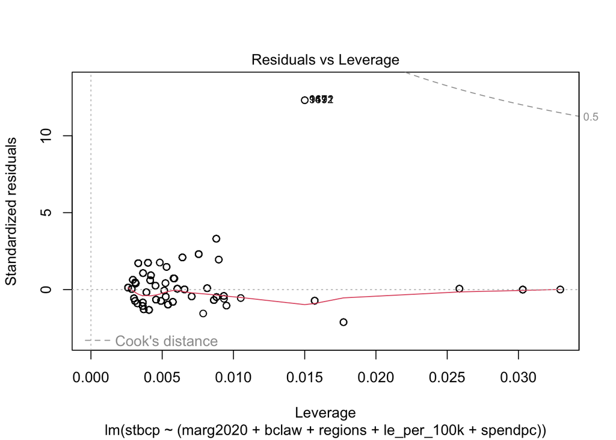

#### Model 2

This model is similar to the previous, except it does not consider the US region. Let’s see if it does a better job at predicting whether a body camera will be turned on or off during a fatal police shooting.

```
##
## Call:
## lm(formula = stbcp ~ (marg2020 + bclaw + spendpc + le_per_100k),
##     data = FD)
##
## Residuals:
##     Min      1Q  Median      3Q     Max
## -0.1722 -0.0554  0.0078  0.0320  0.9106
##
## Coefficients:
##              Estimate Std. Error t value Pr(>|t|)
## (Intercept)  1.29e-01   1.51e-02    8.54  < 2e-16 ***
## marg2020    -1.26e-03   1.53e-04   -8.21  4.3e-16 ***
## bclaw       -1.76e-02   1.44e-02   -1.22     0.22
## spendpc      1.17e-04   1.62e-05    7.25  6.3e-13 ***
## le_per_100k -2.05e-04   2.57e-05   -7.97  2.7e-15 ***
## ---
## Signif. codes:  0 '***' 0.001 '**' 0.01 '*' 0.05 '.' 0.1 ' ' 1
##
## Residual standard error: 0.0807 on 1758 degrees of freedom
## Multiple R-squared:  0.0653, Adjusted R-squared:  0.0632
## F-statistic: 30.7 on 4 and 1758 DF,  p-value: <2e-16
```

```
##    marg2020       bclaw     spendpc le_per_100k
##        2.42        1.03        2.45        1.02
```

```
##        res
## 1 -0.05538
## 2 -0.09714
## 3  0.00778
## 4  0.01558
## 5 -0.03122
## 6 -0.01597
```

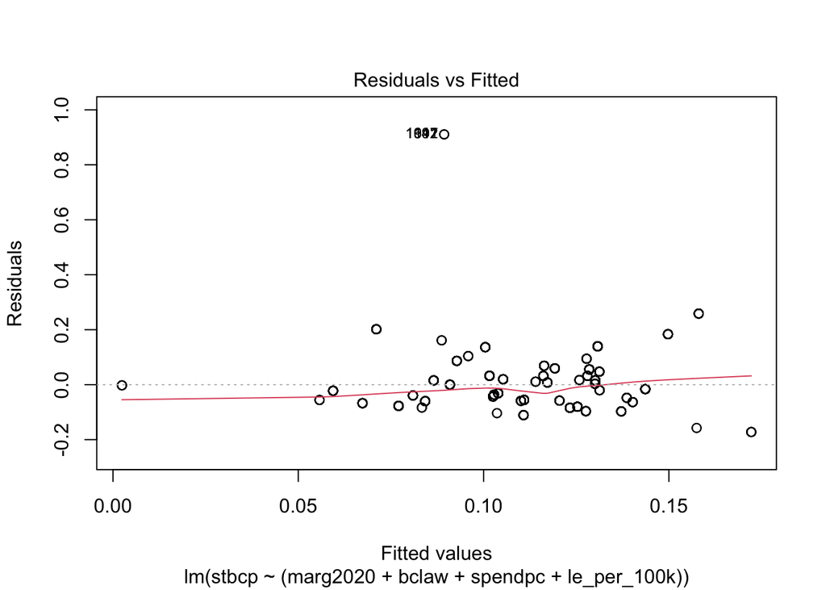

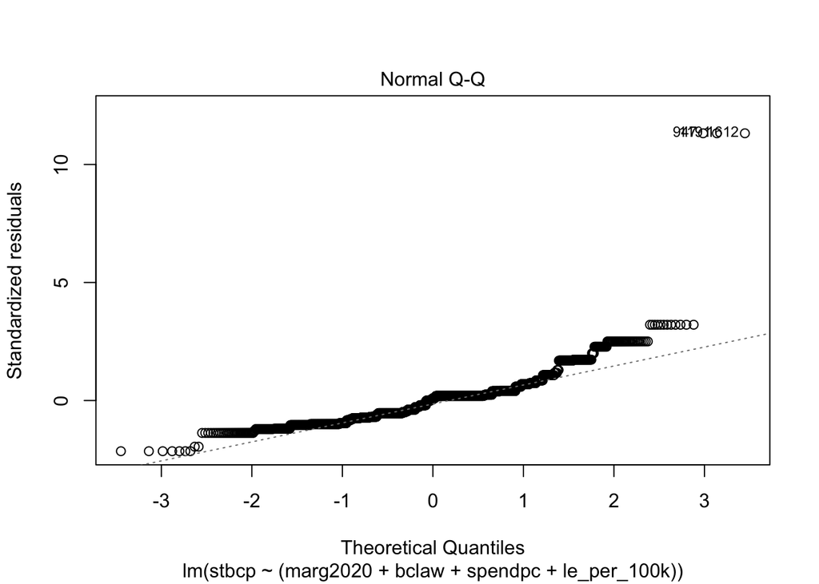

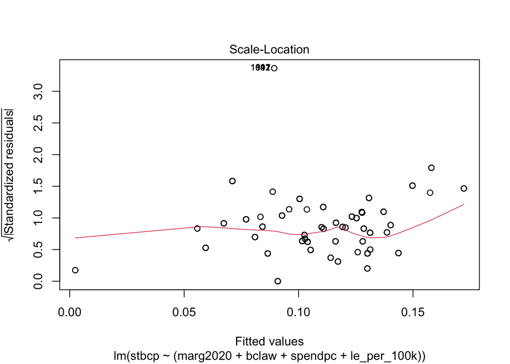

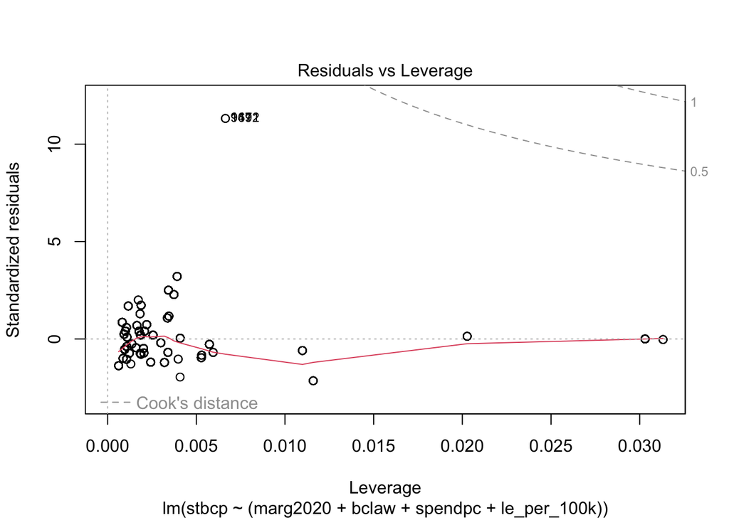

We will now try a polynomial multiple linear regression model, or sometimes called multivariate polynomial regression. This may increase our chances of higher accuracy prediction.

```
##
## Call:
## lm(formula = stbcp ~ (marg2020 + bclaw + regions + le_per_100k +
##     spendpc + I(spendpc * le_per_100k)), data = FD)
##
## Residuals:
##     Min      1Q  Median      3Q     Max
## -0.1631 -0.0504  0.0022  0.0321  0.9585
##
## Coefficients:
##                           Estimate Std. Error t value Pr(>|t|)
## (Intercept)               1.59e-01   4.23e-02    3.77  0.00017 ***
## marg2020                 -5.63e-04   1.71e-04   -3.29  0.00104 **
## bclaw                    -3.62e-02   1.45e-02   -2.50  0.01250 *
## regionsNE                -4.72e-02   9.32e-03   -5.06  4.7e-07 ***
## regionsNW                 3.88e-02   8.12e-03    4.77  2.0e-06 ***
## regionsSE                 2.57e-02   6.54e-03    3.92  9.2e-05 ***
## regionsSW                 7.81e-03   6.88e-03    1.14  0.25610
## le_per_100k              -1.83e-04   9.28e-05   -1.97  0.04915 *
## spendpc                  -4.01e-05   5.94e-05   -0.68  0.49955
## I(spendpc * le_per_100k)  1.63e-07   1.17e-07    1.39  0.16579
## ---
## Signif. codes:  0 '***' 0.001 '**' 0.01 '*' 0.05 '.' 0.1 ' ' 1
##
## Residual standard error: 0.0786 on 1753 degrees of freedom
## Multiple R-squared:  0.115,  Adjusted R-squared:  0.111
## F-statistic: 25.4 on 9 and 1753 DF,  p-value: <2e-16
```

```
##        res
## 1 -0.08069
## 2 -0.10175
## 3  0.02266
## 4  0.01201
## 5 -0.05976
## 6  0.00391
```

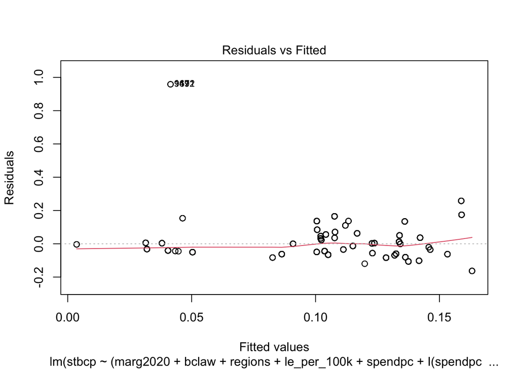

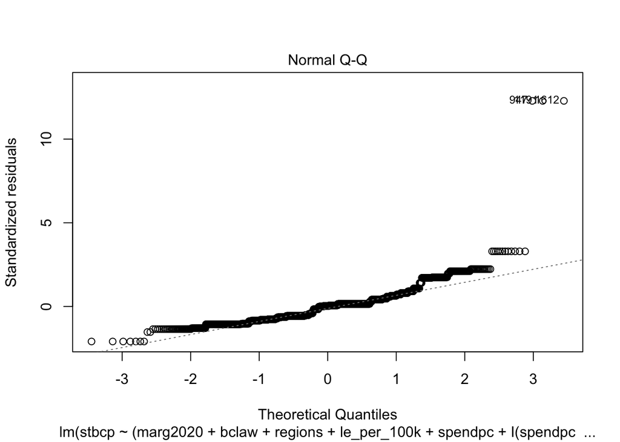

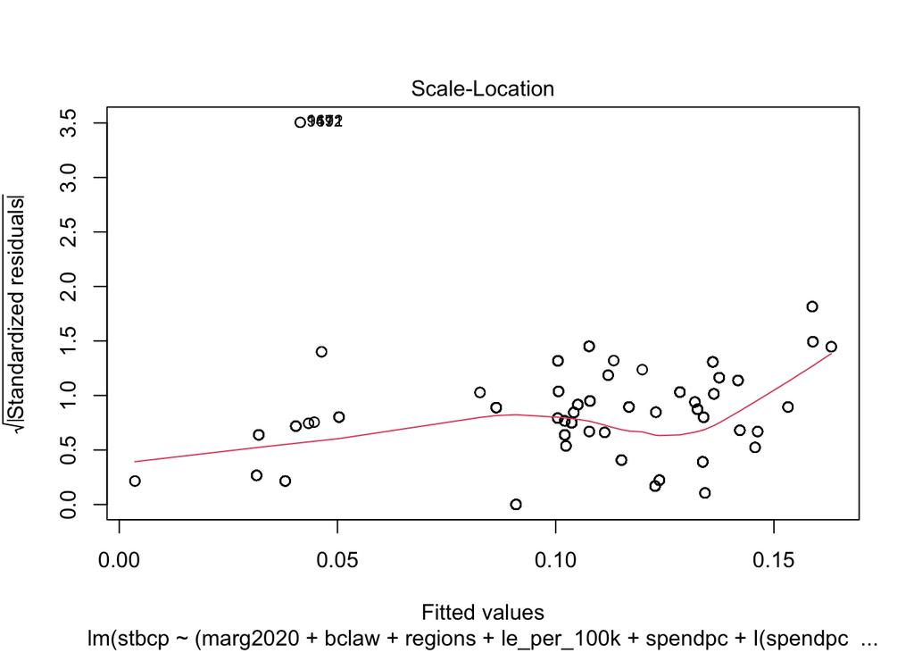

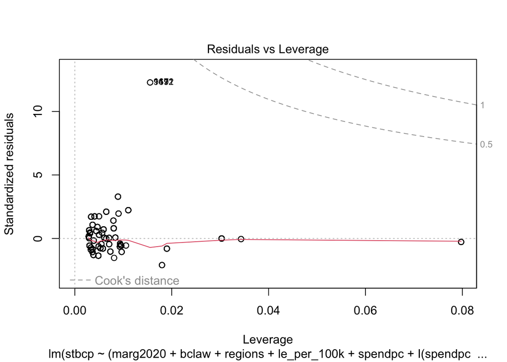

Since lm3 is our best model (per our R^2), lets try to predict a few made up US states. Please notice Eleum and Faraam are identical except their body camera laws. This is the same for GW and HW.

```
##      fit    lwr   upr
## 1 0.0749 0.0439 0.106
```

```
##     fit   lwr   upr
## 1 0.133 0.113 0.152
```

```
##       fit    lwr    upr
## 1 0.00019 -0.032 0.0324
```

```
##     fit   lwr   upr
## 1 0.144 0.104 0.184
```

```
##     fit   lwr   upr
## 1 0.146 0.132 0.161
```

```
##    fit    lwr   upr
## 1 0.11 0.0784 0.142
```

```
##     fit    lwr   upr
## 1 0.106 0.0936 0.118
```

```
##      fit    lwr    upr
## 1 0.0697 0.0407 0.0986
```

Here we can see the difference of fit on states E and F (swung towards Trump) as well as G and H and (swung towards Biden), as well as the effect body camera laws have.

### Part 5: Conclusion

Studying the use of body cameras in police work is an important topic of study for data-driven policy research in the United States. While we hoped to be able to associate this correlation between the U.S. state of observation and whether the body camera was on or off during the shooting to state policy on body cameras to some variable, we were unable to find a strong correlation. Although lm3 was our best model, it is still not a great predictor of statewide body camera usage.

Although we were not able to create a multiple linear regression that served as a predictor of body camera usage, this leads us to an interesting finding: regardless of whether states of body camera laws, well-funded police forces, high numbers of police forces, or progressive state leadership, these variables do not determine whether law enforcement will have their body camera turned on during active police duty. This is actually a major finding. While we have proven that there are significant, quantifiable differences between states as to stbcp, we still do not know why these differences occur.

### Part 6: Bibliography

1. 1,032 people have been shot and killed by police in the past year (November 10, 2022), The Washington Post. https://www.washingtonpost.com/graphics/investigations/police-shootings-database/
2. J. Michtom, US Budget Analysis: Policing and Corrections Spending by State (October 21, 2022), Money Geek. https://www.moneygeek.com/living/state-policing-corrections-spending/
3. Joe Biden has been declared winner, toppling Donald Trump after four years of upheaval in the White House (November 8, 2022), Politico. https://www.politico.com/2020-election/results/president/
4. Police Officers by State 2022 (2022), World Population Review. https://worldpopulationreview.com/state-rankings/police-officers-by-state